# CMPINF 2130 Summer 2021 - Week 06

To overcome these limitations we can combine a special kind of scatter plot known as a **stripplot** or **beeswarm plot** with a **violin plot** and the boxplot.

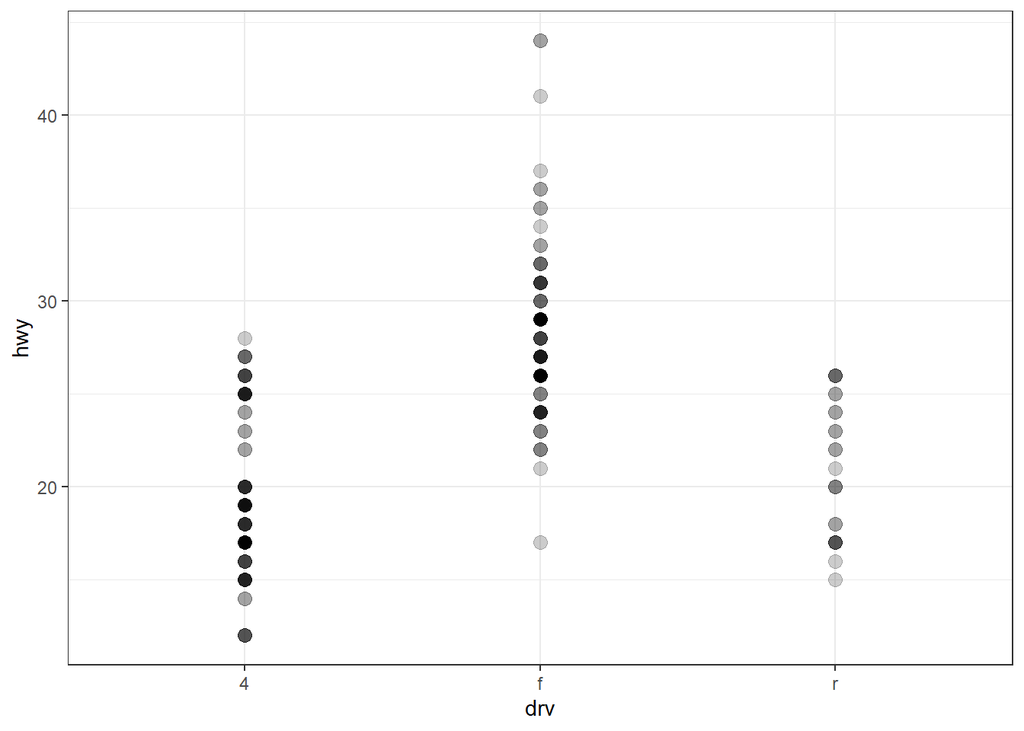

```r
mpg %>%
  ggplot(mapping = aes(x = drv, y = hwy)) +
  geom_point(alpha = 0.2, size = 3) +
  theme_bw()
```

Adding random **jitter** can help distinguish individual markers.

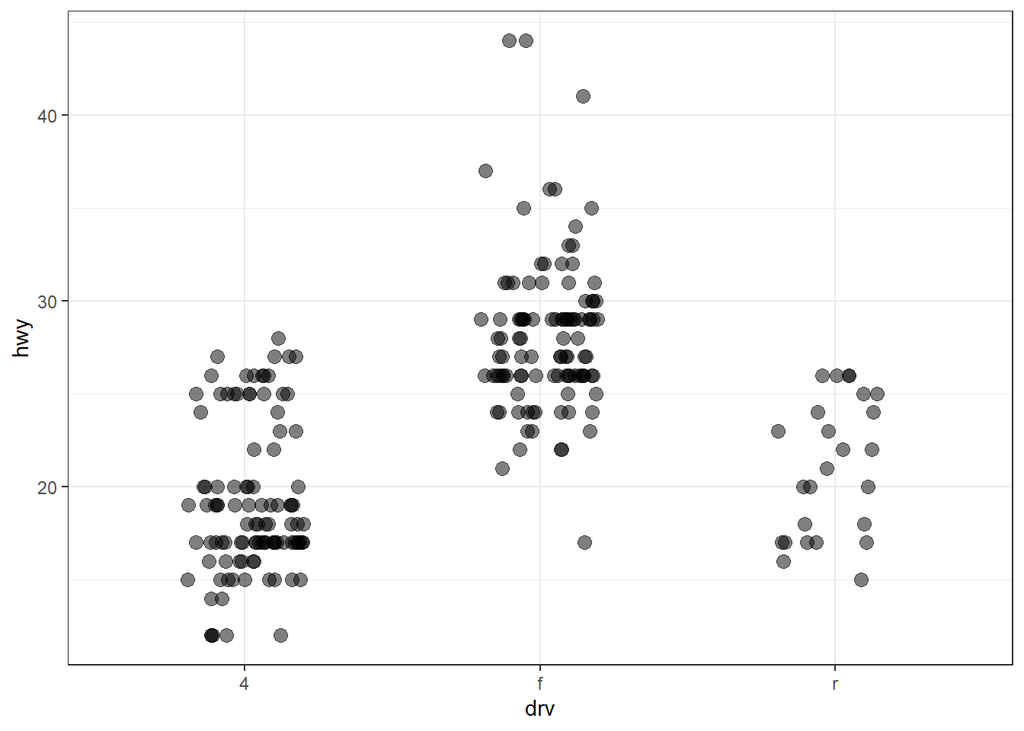

```r
mpg %>%
  ggplot(mapping = aes(x = drv, y = hwy)) +
  geom_jitter(alpha = 0.5, size = 3,
              height = 0, width = 0.2) +
  theme_bw()
```

Useful to show the boxplot to help summarize important statistics.

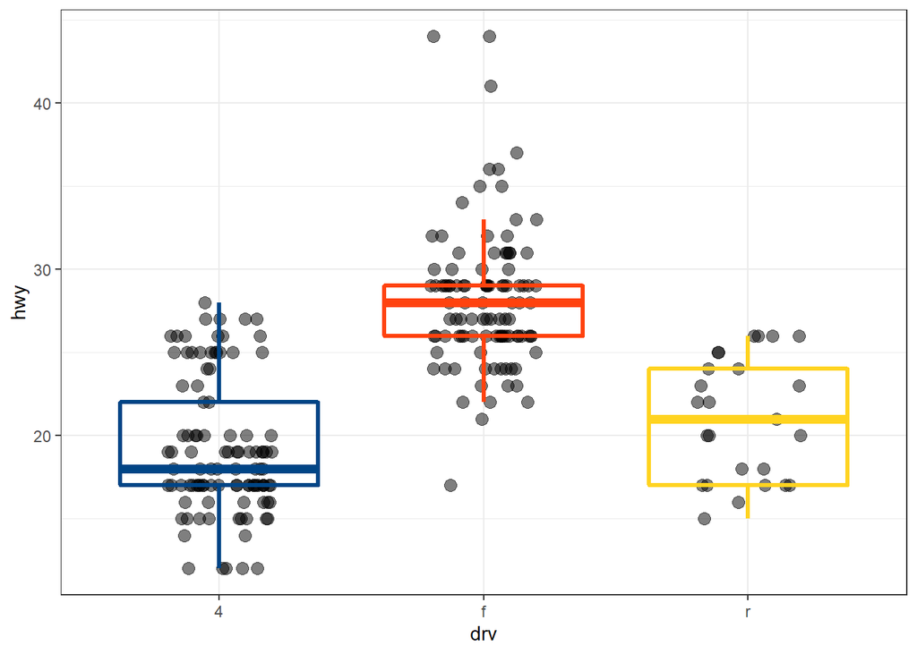

```r
mpg %>%
  ggplot(mapping = aes(x = drv, y = hwy)) +
  geom_jitter(alpha = 0.5, size = 3,
              height = 0, width = 0.2) +
  geom_boxplot(fill = NA,
               mapping = aes(color = drv),
               size = 1.15,
               outlier.shape = NA) +
  ggthemes::scale_color_calc(guide = FALSE) +
  theme_bw()
```

Overlay the density estimate via a **violin** plot.

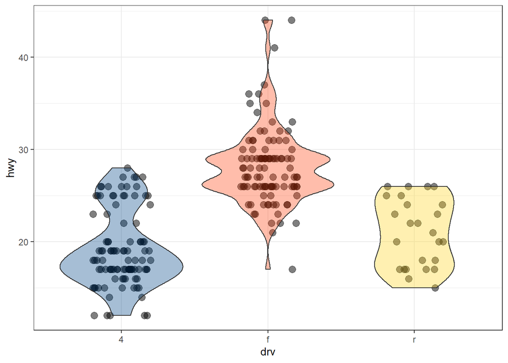

```r
mpg %>%
  ggplot(mapping = aes(x = drv, y = hwy)) +
  geom_jitter(alpha = 0.5, size = 3,
              height = 0, width = 0.2) +
  geom_violin(mapping = aes(fill = drv),
              alpha = 0.35) +
  ggthemes::scale_fill_calc(guide = FALSE) +
  theme_bw()
```

Add in the density and the boxplot on top of the strip plot.

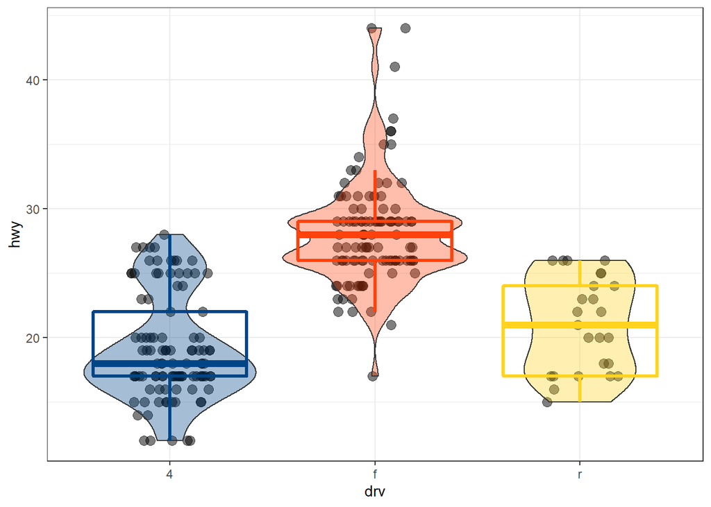

```r
mpg %>%
  ggplot(mapping = aes(x = drv, y = hwy)) +
  geom_jitter(alpha = 0.5, size = 3,
              height = 0, width = 0.2) +
  geom_violin(mapping = aes(fill = drv),
              alpha = 0.35) +
  geom_boxplot(mapping = aes(color = drv),
               size = 1.15,
               fill = NA,
               outlier.shape = NA) +
  ggthemes::scale_fill_calc(guide = FALSE) +
  ggthemes::scale_color_calc(guide = FALSE) +
  theme_bw()
```

We created by hand the rain cloud plot! There are multiple useful extension packages which can streamline the creation of this plot and make it cleaner, prettier, and easier to look at. Please see the following links for those extensions if you are interested:

[rain cloud plots in ggplot2](https://z3tt.github.io/Rainclouds/)

[rain clouds useful discussion on box and violin limitations](https://www.cedricscherer.com/2021/06/06/visualizing-distributions-with-raincloud-plots-with-ggplot2/)

The second link in particular has useful discussion around the limitations of boxplots and violin plots and how combining them in a coherent way can help overcome those limitations.